# Insights About Myself (IAM): *Bolsas de Plástico.*

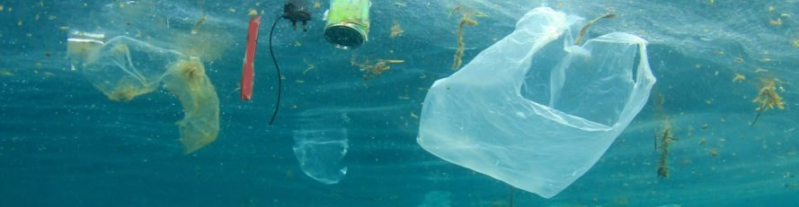

## Índice

- Introducción
  - El contexto
  - La idea
  - Los hechos
  - El objetivo
  - La metodología
- Captura de datos
  - Descarga de datos
  - Procesado de datos
    - Extracción del texto cotenido en las imágenes
    - Estructuración del texto
    - Extracción de información relevante
- Validación de los datos
- Explotación de los datos
- Conclusiones
- Agradecimientos

## Introducción

### El contexto

La mayoría de las personas somos conscientes (y si no deberíamos) de que vivimos en una especie de gran hermano digital. Un gran número de empresas/gobiernos siguen nuestros pasos a través de internet, analizan nuestros patrones de consumo, estudian los textos que escribimos, la forma en la que nos desplazamos, etc. No me entendáis mal, no es que yo sea un “conspiranoide” o piense que existe alguna mala fe en la adquisición y en el estudio de esos datos. Creo que en la mayoría de los casos (por desgracia no en todos) es totalmente legítimo y que aporta un gran valor a la sociedad. Esta es una cuestión que involucra aspectos éticos en los que no voy a entrar y en que cada uno tendrá su propia opinión. Los datos a los que me refiero, por norma general, quedan a disposición de las instituciones que los capturan para los usos que ellos consideran oportunos buscando sus propios objetivos y frecuentemente sin pensar en los beneficios que nos pueden aportar a nosotros como individuos. De este contexto surge el concepto de **Insights About Mysef** (juego de palabras con I AM, "yo soy" en inglés), recuperar el control sobre nuestros datos y usarlos nuestro propio beneficio y en el de nuestro entorno.

Soy perfectamente consciente de que no todo el mundo tiene los conocimientos necesarios para la explotación de sus propios datos. Lo que más tarde expondré (técnicas y códigos) deben considerarse más como una prueba de concepto, que algo que se pueda usar en el día a día (por el momento 😉).

### Los hechos

- Cada segundo, se utilizan 160.000 bolsas de plástico en todo el mundo.
- La cantidad de petróleo que se necesita para producir una bolsa de plástico podría conducir un automóvil 11 metros. ¿No parece mucho? Multiplícalo por el número de arriba.
- Una bolsa de plástico se usa durante un promedio de 12 minutos.
- Se necesitan 500 años (o más) para que una bolsa de plástico se degrade en un vertedero. Y ni siquiera se degrada completamente.
- Solo el 1% de las bolsas de plástico se devuelven para su reciclaje.
- 100.000 animales marinos mueren anualmente por causas relacionadas directamente con las bolsas de plástico.
- Las bolsas de plástico se encuentran entre los 12 desechos más comunes en las limpiezas costeras.
- Si uniéramos todas las bolsas de plástico del mundo, darían la vuelta al mundo 4.200 veces.
- Si persona usara bolsas de plástico recicladas durante toda su vida, estaría eliminando 22.000 bolsas de plástico del medio ambiente.
- ...

**Fuentes consultadas:**

- [blog.padi.com](https://blog.padi.com/2017/03/27/7-facts-plastic-bags-will-change-way-use/)
- [www.biologicaldiversity.org](https://www.biologicaldiversity.org/programs/population_and_sustainability/sustainability/plastic_bag_facts.html)

### La idea

El **REAL DECRETO 293/2018, de 18 de mayo** regula el uso de las bolsas de plástico en los comercios. Este real decreto obliga a los comercios a no suministrar cierto tipo bolsas de plástico de forma gratuita. Desde mi punto de vista un clásico del comportamiento del humano del "primer mundo". Hasta que no nos tocan el bolsillo no tomamos conciencia de los problemas que nos rodean, por muchas campañas de concienciación a las que uno se vea expuesto.

Como era de esperar los primeros días de la prohibición era habitual ver como los clientes llevaban sus propias bolsas de al supermercado. Personalmente, no creo que a todo el mundo se le hubiera despertado de repente la conciencia medioambiental sino que más bien querían ahorrase unos centimillos (aunque puede que yo sea un poco mal pensado 🤷‍). En mi caso, yo consideraba que unos céntimos extra por compra no iban a hundir mi economía, por lo que cada vez que iba al super compraba las bolsas que necesitaba sin darle muchas vueltas al asunto (sé que no es para estar orgulloso pero así era). Y así fue durante un tiempo hasta que como suele suceder algo te abre los ojos.

No hace mucho, teniendo una charla banal con una persona obviamente más comprometida con el medio ambiente que yo, de origen asturiano pero que actualmente reside en una gran ciudad, me comentaba:

> "Una cosa que me extrañaba mucho en Asturias es que muy poca gente lleva su propia bolsa al supermercado. Donde yo vivo lo habitual es llevarla"

Tengo que reconocer que esa afirmación me hizo pasar un poco de vergüenza 😳 pero también me hizo reflexionar. A los asturianos nos encanta presumir de nuestro **Paraíso Natural** pero está claro que en muchos aspectos no le prestamos toda la atención que se merece. Me extrañó que personas que viven en grandes ciudades, que en principio no tienen un contacto tan estrecho con la naturaleza, estén más concienciados que nosotros, que prácticamente en media hora de trayecto, podemos estar en medio de ningún sitio rodeados de naturaleza.

Hacía tiempo que rondaba por mi cabeza la idea de empezar a analizar los datos generados por mí, de forma directa o indirecta para de alguna manera, conocerme mejor. Esta conversación fue el catalizador que hizo que me pusiera manos a la obra. ¿Cuántas bolsas de plástico había consumido sin tener necesidad de ello? ¿Cuánto plástico había derrochado? Con el objetivo de responder a estas preguntas (y en el futuro, muchas más) empecería a analizar mis patrones de consumo.

Está claro que uno no sabe nunca donde va a encontrar la inspiración para su siguiente proyecto. Ya veis, de una pequeña charla aparentemente intranscendente surgió la idea de crear "**Insights About Myself (IAM):** *Bolsas de Plástico*", del que espero que sea solo el principio de un proyecto mucho más ambicioso.

### El objetivo

Este trabajo persigue tres objetivos:

- Uno que podría considerarse más abstracto y que consiste en tomar conciencia de la importancia de los datos que generamos, y de como estos explotados de una manera adecuada, pueden ayudarnos a mejorar nuestra vida y nuestro entorno.
- Uno más técnico, mostrando un ejemplo de cómo capturar, validar y explotar nuestros datos.
- Y finalmente un objetivo social, el de despertar la conciencia medioambiental de algún lector que la pudiera tener algo adormecida 😴.

### La metodogía

Los datos que se van a utilizar en este trabajo proceden de las compras realizadas por mí, durante el año 2020 (desde finales de febrero, que es cuando me hice la tarjeta de fidelización) en una conocida cadena de supermercados. Casi todas las compras las realizo en esos supermercados, por lo que los datos son totalmente representativos de mis hábitos de consumo.

El trabajo se divide en tres grandes bloques:

- Captura de datos. En este bloque se explicará cómo obtener los datos.
- Validación. Como su nombre indica, en esta sección se expondrá un sistema de validación automático de los datos y las acciones correctivas necesarias en el caso de que existieran problemas en ellos.
- Explotación. En este apartado se usarán los datos obtenidos en los dos pasos anteriores para resolver un conjunto de cuestiones relacionadas con los objetivos expuestos en el apartado anterior.

Para la realización de este proyecto se ha usado *[Python](https://www.python.org/)*, junto a su magnifico conjunto de librerías (*[pandas](https://pandas.pydata.org/)*, *[numpy](https://numpy.org/)*, *[matplotlib](https://matplotlib.org/)*, *[selenium](https://pypi.org/project/selenium/)*, por nombrar solo algunas) en combinación con las tecnologías que ofrece *Google* en su producto *[Google Cloud](https://cloud.google.com)*.

## Captura de datos

### Descarga de los tickets

Nuestros supermercados favoritos, nos ofrecen, a través de la página web que pone a disposición de sus clientes, la posibilidad de acceder a los tickets de nuestras compras. Los tickets están organizados por año y por mes como se puede ver en la imagen:

[figure not shown]

Si pinchamos en el 👁️ podremos ver la imagen del ticket correspondiente. Lamentablemente, la opción de descargarlo no existe (*#TODO* Añadir botón de descarga 🙏). Pero no hay problema, años de experiencia en el mundo de la navegación web me hacen pesar que, si uso el botón derecho del ratón sobre la imagen, la opción de descargar aparecerá como por arte de magia y voilà ahí está:

[figure not shown]

Queremos descargar todos los tickets del año 2020. Una opción sería ir ticket por ticket viéndolos y descargándolos, pero ese método tiene dos problemas:

- No escala bien, imaginad que queremos extender el estudio a diez años por ejemplo, menudo trabajo hercúleo.
- No es el estilo de un Data Scientist 😎.

¡Empieza la diversión! Para poder descargarnos los tickets de manera automática tendremos que usar técnicas de [Web Scraping](https://en.wikipedia.org/wiki/Web_scraping). A grandes rasgos, esta tarea se puede dividir en dos partes:

- Navegación automática.
- Extracción de la información relevante.

Para la navegación automática me he decidido por el uso de los [bindigns](https://pypi.org/project/selenium/) para [Python](https://www.python.org) del [Selenium WebDriver](https://www.selenium.dev/). En particular, he usado el driver de [Google Chrome](https://chromedriver.chromium.org/downloads) que se puede descargar [aquí](https://chromedriver.chromium.org/downloads). Me he decantado por esta opción por ser la más sencilla (todo el mundo sabe que los matemáticos tenemos fama de ser vagos y bueno, de otras cosas que no voy a detallar aquí 😉). Esta opción no sería la más adecuada para sitios webs grandes, pero para el caso que nos atañe es suficientemente buena.

Para los amantes del *DIY* (Do It Yourself), creo que es importante mencionar que, independientemente de la elección del lenguaje de programación (en este caso yo usaré *Python*), para poder realizar cualquiera de las tareas es necesario tener un conocimiento bastante profundo de varias tecnologías web que paso a enumerar:

- Protocolo [HTTP](https://en.wikipedia.org/wiki/Hypertext_Transfer_Protocol)
- Lenguaje XPath
- Lenguaje HTML

**¡Aviso!** Antes de entrar en materia y pasar a describir el código fuente que se ha utilizado se han de tener en cuenta los siguientes aspectos:

1. El Web Scrapping a menudo genera controversia. Algunas personas sugieren que puede llegar a infringir derechos de autor y/o violar las condiciones de uso de algunos sitios web.
2. Este código está diseñado para descargarse MIS DATOS, los cuales obviamente me pertenecen. En ningún caso está diseñado para una descarga masiva de datos de carácter personal de otros usuarios o cualquier otro tipo de datos (código fuente, imágenes, etc.).
3. Otra forma de obtener los datos (no tan divertida claro) sería haciendo uso de los derechos que me otorga la LPDCP (Ley de Protección de Datos de Carácter Personal).
4. Aunque sean mis datos, quiero y debo ser lo más respetuosos posible y hacer todo lo que esté en mi mano para no interferir en el correcto funcionamiento de los servidores que alojan dichos datos. Por este motivo, el código incluye pausas entre peticiones para evitar sobrecargar los sistemas que sirven el contenido web.

Una vez dicho esto ... ¡Al turrón!

Lo primero que haremos será importar todas las librerías/módulos que vamos a necesitar:

```python
import os
import re
import csv
import time
from datetime import datetime
import urllib
import requests
import numpy as np
from bs4 import BeautifulSoup
from selenium import webdriver
from selenium.common.exceptions import TimeoutException
from selenium.webdriver.common.by import By
from selenium.webdriver.support import expected_conditions as EC
from selenium.webdriver.support.ui import WebDriverWait
```

Los conjuntos de datos que se vayan creando y que requieran persistencia se almacenarán en archivos del tipo [*CSV*](https://en.wikipedia.org/wiki/Comma-separated_values). El nombre *CSV* engloba a una familia de tipos de archivos y cada tipo tiene sus propias características como podrían ser: el delimitador, el entrecomillado, etc. A continuación, definiremos una clase que establecerá las características de todos los archivos generados, lo que a la postre facilitará su manipulación:

```python
class CustomDialect(csv.Dialect):

    """Describe the properties of custom-generated CSV files."""

    delimiter = ','
    quotechar = '"'
    doublequote = True
    skipinitialspace = False
    lineterminator = '\n'
    quoting = csv.QUOTE_MINIMAL


csv.register_dialect('custom', CustomDialect)  # Dialect registration for future use
```

Para medir el progreso de las distintas tareas vamos a definir la siguiente clase:

```python
import math

class ProgressBar(object):

    def __init__(self, count, steps, task='Task', marker='=='):

        self.end = count
        self.steps = steps
        self.last_step = 0
        self.current_step = 0
        self.current = 0
        self.step_size = count / steps
        self.marker = marker
        self.showed = False
        self.task = task

    def __iadd__(self, other):

        self.current = min(self.current + other, self.end)
        self.current_step = math.floor(self.current / self.step_size)
        return self

    def show(self):

        if self.last_step < self.steps:
            if not self.showed:
                print('{}: |'.format(self.task), end='')
                self.showed = True
            print(self.marker * (self.current_step - self.last_step) , end='')
            self.last_step = self.current_step
            if self.current_step == self.steps:
                print('| Done!')
```

Su función es imprimir por pantalla una barra de progreso para tener un *feedback* en aquellas tareas que tardan en ejecutarse (como la descarga de las imágenes). Solo tiene un fin estético por lo que no es importante para la compresión del resto del proceso.

Ahora definiremos un conjunto de constantes necesarias para el funcionamiento del proceso de descarga. Todas son bastante auto explicativas salvo las dos últimas: `CHROME_VERSION` y `WEBDRIVER_PATH`. Para que el script funcione, es necesario tener instalado el navegador web [Google Chrome](https://www.google.com/intl/es/chrome/) y habernos descargado el *webdriver* compatible con la versión instalada. Estas dos variables indican, respectivamente, la versión del *Google Chrome* que tenemos instalada en nuestro *PC* y el directorio donde está almacenado el *webdriver*.

```python
USER = ''
PASSWORD = ''
YEARS = [2020]
WAIT_TIME = 1  # Time between requests
TICKETS_OUTPUT_DIR = '.tickets/'
WEBDRIVER_LOG_DIR = '.webdrivers/log'
CHROME_VERSION = 87
WEBDRIVER_PATH = '.webdrivers/chromedriver_{}.exe'.format(CHROME_VERSION)
```

Creamos el directorio (si no existiera) donde se almacenarán los tickets descargados:

```python
if not os.path.isdir(TICKETS_OUTPUT_DIR):
    os.mkdir(TICKETS_OUTPUT_DIR)
```

Definimos un par de *helpers* básicos que nos ayudarán a formatear de forma correcta tanto las fechas como los números de los contenidos extraídos del código *HTML*:

```python
def parse_date(date_str):
    """Parses dates"""
    return datetime.strptime(date_str, '%d-%m-%Y %H:%M:%S')

def parse_currency(currency_str):
    """Parses currency"""
    return float(currency_str[:-2].replace(',', '.'))
```

Después de un exhaustivo análisis del código *HTML*, he averiguado que para poder descargarnos las imágenes de los tickets necesitamos dos identificadores:

- Un identificador único que llamaremos *token*. Este se obtiene de los enlaces a los tickets (👁️).
- Otro identificador que no sé muy bien como catalogar que se denomina *plid*. Para obtener este valor es necesario extraerlo directamente del código *HTML*. En particular, se encuentra en un fragmento de código JavaScript.

El *helper* que definimos a continuación, sirve para obtener el segundo de los identificadores.

```python
def get_plid(bs):

    """Extract plid from JavaScript"""

    id_regex = r'getPlid:\s*function\(\)\s*\{\s*return\s+"(\d+)";\s*}'
    for scr in bs.find_all('script'):
        if scr.string is not None:
            m = re.search(id_regex, scr.string)
            if m:
                plid = m.group(1)
                return plid
    return None
```

Las siguientes variables contienen todas las expresiones XPath que vamos a necesitar. No entraré en detalle de como he obtenido esas expresiones (por no aburrir al lector 😅) pero si mencionaré que ha sido necesario un estudio meticuloso del código fuente del sitio web. Creo que los nombres de las variables identifican perfectamente los elementos web a los que se refieren y por lo tanto, no me detendré a explicarlos uno por uno.

```python
id_input_xpath = "//input[@title='DNI']"
pass_input_xpath = "//input[@title='Contraseña']"
submit_button_xpath = "//button[@type='submit']"
year_selector_xpath = "//td[@class='month-picker-title']/a"
year_selector_next_xpath = "//td[@class='month-picker-next']/a"
year_selector_prev_xpath = "//td[@class='month-picker-previous']/a"
month_selector_xpath = "//table[@class='month-picker-month-table']/tr[{0}]/td[{1}]/a"
year_selector_table_xpath = "//table[@class='month-picker-month-table']//tr//td/a[text()='{year}']"
```

A no ser que tengáis muy mala memoria (🐟) recodaréis que os dije que para descargar una imagen eran necesarios dos identificadores. Pues bien, a continuación mostramos la estructura general de las [urls](https://en.wikipedia.org/wiki/URL) de descarga de las imágenes de los tickets:

```python
ticket_ulr = 'https://clientes.alimerka.es/c/portal/layout?' + \
             'p_l_id={plid}' + \
             '&doAsUserId=' + \
             '&p_p_cacheability=cacheLevelPage' + \
             '&p_p_id=mistickets_WAR_actividadportlet' + \
             '&p_p_lifecycle=2' + \
             '&p_p_resource_id=getImage' + \
             '&_mistickets_WAR_actividadportlet_ticketToken={token}'
```

Fijaros en los dos parámetros que se requieren (entre llaves): *plid* y *token*.

Una vez expuesto lo anterior, pasaremos a describir el funcionamiento general del script de extracción. La idea es muy simple, básicamente hace lo que haríamos nosotros si tuviéramos que hacer el trabajo a mano:

1. Se logea en el sitio web
2. Recorre todos los meses de los años que le hemos indicado para obtener los *token* y los *plid*. Con esos identificadores se descarga los tickets a un directorio local mediante el uso de la *url* presentada anteriormente.
3. Si recordáis, al seleccionar cada uno de los meses aparecía una tabla resumen (ver figuras) de las compras de dicho mes. Esta tabla contiene las fechas y los importes totales de los tickets de ese mes. Esa información también se almacena, veremos para qué, más adelante.
4. Cerramos sesión en el sitio web.

El código fuente sería el siguiente:

```python
data_summary = [] # It will contain all summary info
print('Initializing browser engine: ', end='')
options = webdriver.ChromeOptions()
options.add_argument('headless')  # Run background
options.add_argument('verbose')  # Verbosity control. You can see log in WEBDRIVER_LOG_DIR/chromedriver.log

# Context ensures that session is closed at the end of script
with webdriver.Chrome(executable_path=WEBDRIVER_PATH, service_log_path=os.path.join(WEBDRIVER_LOG_DIR, 'chromedriver.log'),
                      options=options) as driver:

    time.sleep(5) # Waiting for Chorme to open
    print('Done!')
    # Start login process
    driver.get('https://clientes.alimerka.es/')
    id_input_element = driver.find_element_by_xpath(id_input_xpath)
    id_input_element.send_keys(USER)
    pass_input_element = driver.find_element_by_xpath(pass_input_xpath)
    pass_input_element.send_keys(PASSWORD)
    submit_button_element = driver.find_element_by_xpath(submit_button_xpath)
    submit_button_element.click()
    # End login process

    driver.get('https://clientes.alimerka.es/group/portalcliente/tickets')

    calendar = np.array([['January', 'February', 'March'],
              ['April', 'May', 'June'],
              ['July', 'August', 'September'],
              ['October', 'November', 'December']])


    progress = ProgressBar(len(YEARS) * 12, 10, task='Downloading tickets')
    progress.show()

    for year in YEARS:

        driver.get('https://clientes.alimerka.es/group/portalcliente/tickets')
        year_selector = driver.find_element_by_xpath(year_selector_xpath)
        current_year = int(year_selector.get_attribute("innerHTML").strip().split()[1])

        # Select correct year
        if current_year != year:
            year_selector.click()
            year_found = False
            if (current_year - year) >= 0:
                times = int(np.floor(1 - (year - current_year + 3)/12))
                year_selector_prev = driver.find_element_by_xpath(year_selector_prev_xpath)
                for _ in range(times):
                    year_selector_prev.click()
                driver.find_element_by_xpath(year_selector_table_xpath.format(year=year)).click()
            else:
                times = int(np.ceil((year - current_year - 7) / 12))
                year_selector_next = driver.find_element_by_xpath(year_selector_next_xpath)
                for _ in range(times):
                    year_selector_next.click()
                driver.find_element_by_xpath(year_selector_table_xpath.format(year=year)).click()

        # Start download
        for (i, j) in np.ndindex(*calendar.shape):
            month_selector_element = driver.find_element_by_xpath(month_selector_xpath.format(i + 1, j + 1))
            month_selector_element.click()
            try:
                WebDriverWait(driver, 10).until(
                    EC.presence_of_element_located((By.CLASS_NAME, 'table-ticket')))
            except TimeoutException as e:
                progress +=1
                progress.show()
                continue

            html = driver.page_source
            soup = BeautifulSoup(html, features='html.parser')
            plid = get_plid(soup)
            tickets_table = soup.select_one('.table-ticket').find('table')

            # Download all month tickets
            with requests.Session() as s:
                request_cookies_browser = driver.get_cookies()  # Get cookies from webdriver
                [s.cookies.set(c['name'], c['value']) for c in request_cookies_browser] # Set cookies to keep session active
                for n, row in enumerate(tickets_table.find('tbody').find_all('tr')[:]):
                    columns = row.find_all('td')
                    ticket_data = {'ticket_id': columns[0].get_text().strip().zfill(6),  # Fixed id length of 6 chars
                                   'ticket_date': parse_date(columns[1].get_text().strip()),
                                   'total_ticket': parse_currency(columns[2].get_text().strip())
                                   }
                    link_column = columns[-1]
                    token = link_column.find('a').get('data-tickettoken')
                    res = s.get(ticket_ulr.format(plid=plid, token=urllib.parse.quote(token, safe='')))  # Download image
                    data_summary.append(ticket_data)
                    open(os.path.join(TICKETS_OUTPUT_DIR, '{ticket_id}.jpg'.format(ticket_id=ticket_data['ticket_id'])),
                         'wb').write(res.content)
                    time.sleep(WAIT_TIME)  # Avoid overloading the servers

            progress +=1
            progress.show()

# Write summary data to CSV
print('Writing summary data to file: ', end='')
with open(os.path.join(TICKETS_OUTPUT_DIR, 'tickets_summary.csv'), 'w', encoding="utf-8") as outfile:
    fieldnames = ['ticket_id', 'ticket_date', 'total_ticket']
    writer = csv.DictWriter(outfile, fieldnames=fieldnames, dialect='custom')
    writer.writeheader()
    writer.writerows(data_summary)
print('Done!')
```

```
Initializing browser engine: Done!
Downloading tickets: |====================| Done!
Writing summary data to file: Done!
```

En este punto ya tenemos todos los tickets del año 2020 descargados en nuestro sistema de archivos local. Estoy seguroque incluso podemos obtener ya algunos *insights* de los datos. Para ello, vamos a hacer uso de dos librerías que podrían considerarse esenciales para un científico de datos que utilice *Python* para sus proyectos: [pandas](https://pandas.pydata.org/) y [matplotlib](https://matplotlib.org/).

```python
%matplotlib inline
import pandas as pd
from matplotlib import pyplot as plt
```

Primero comprobaremos que las imágenes se han descargado correctamente. Para ello, mostraremos la cabecera de uno de los tickets (espero que no aparezca ninguna compra embarazosa 😅):

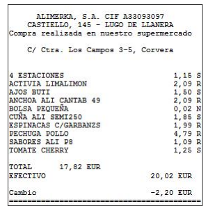

```python
import imageio
sample_ticket_id = '007347'
im = imageio.imread(os.path.join(TICKETS_OUTPUT_DIR, '{}.jpg'.format(sample_ticket_id)))  # Load last image
fig, ax = plt.subplots(figsize=(5, 15))
ax.imshow(im[0:290, ::], cmap='gray', vmin=0, vmax=255)
ax.set(xticks=(), yticks=());
```

A continuación, cargaremos los datos de las fechas y de los importes extraídos en un *DataFrame* y mostraremos algunas gráficas y estadísticas (ese tipo de cosas que tanto nos gusta a los Data Scientist 🥰). No perderé mucho tiempo en su análisis por no ser el tema que nos ocupa. Todavía hay mucho trabajo por delante 💪.

```python
tickets_summary_df = pd.read_csv(os.path.join(TICKETS_OUTPUT_DIR, 'tickets_summary.csv'), sep=',',
                                 decimal='.', parse_dates=['ticket_date'])
tickets_summary_df.head(5)
```

|  | ticket_id | ticket_date | total_ticket |
| --- | --- | --- | --- |
| 0 | 7295 | 2020-02-28 17:08:59 | 10.34 |
| 1 | 9992 | 2020-03-31 16:33:35 | 20.01 |
| 2 | 9659 | 2020-03-28 14:25:09 | 30.24 |
| 3 | 7439 | 2020-03-24 15:42:11 | 41.10 |
| 4 | 5645 | 2020-03-18 15:23:15 | 31.35 |

Añadiremos algunos campos nuevos para facilitar la visualización y comprensión de los datos:

```python
tickets_summary_df['year'] = tickets_summary_df.apply(lambda x: int(x.ticket_date.strftime('%Y')), axis=1)
tickets_summary_df['month'] = tickets_summary_df.apply(lambda x: x.ticket_date.strftime('%B'), axis=1)
tickets_summary_df['week'] = tickets_summary_df.apply(lambda x: int(x.ticket_date.strftime('%W')), axis=1) # First day monday
tickets_summary_df['day'] = tickets_summary_df.apply(lambda x: x.ticket_date.strftime('%A'), axis=1)
tickets_summary_df['day_of_week'] = tickets_summary_df.apply(lambda x: (int(x.ticket_date.strftime('%w')) - 1) % 7, axis=1)
tickets_summary_df.head(5)
```

|  | ticket_id | ticket_date | total_ticket | year | month | week | day | day_of_week |
| --- | --- | --- | --- | --- | --- | --- | --- | --- |
| 0 | 7295 | 2020-02-28 17:08:59 | 10.34 | 2020 | February | 8 | Friday | 4 |
| 1 | 9992 | 2020-03-31 16:33:35 | 20.01 | 2020 | March | 13 | Tuesday | 1 |
| 2 | 9659 | 2020-03-28 14:25:09 | 30.24 | 2020 | March | 12 | Saturday | 5 |
| 3 | 7439 | 2020-03-24 15:42:11 | 41.10 | 2020 | March | 12 | Tuesday | 1 |
| 4 | 5645 | 2020-03-18 15:23:15 | 31.35 | 2020 | March | 11 | Wednesday | 2 |

Veamos algunos hechos sobre los datos de los que disponemos hasta ahora:

```python
from IPython.display import Markdown as md
mrkdwn = ''
fact= '- Los datos se refieren al periodo temporal comprendido entre **{start}** y **{end}**.\r\n'
mrkdwn += fact.format(start=tickets_summary_df.ticket_date.min().strftime('%d/%m/%Y'),
                      end=tickets_summary_df.ticket_date.max().strftime('%d/%m/%Y'))
fact = '- En ese tiempo he ido **{count}** veces a supermercado.\r\n'
mrkdwn += fact.format(count=len(tickets_summary_df))
fact = '- Me he gastado un total de **{total:.2f} €**.\r\n'
mrkdwn += fact.format(total=tickets_summary_df.total_ticket.sum())
fact = '- El coste medio de cada visita ha sido de **{cost:.2f} €**.\r\n'
mrkdwn += fact.format(cost=tickets_summary_df.total_ticket.mean())
fact = '- Mi presuesto mensual destinado al super es de aproximadamente **{budget:.2f} €**.\r\n' # February exluded
mrkdwn += fact.format(
    budget=tickets_summary_df[tickets_summary_df.month!='February'].groupby('month').sum().total_ticket.mean())
fact = '- De media voy **{visits:.2f}** veces al mes.\r\n'
mrkdwn += fact.format(visits=tickets_summary_df.groupby('month').agg({'total_ticket': 'count'}).total_ticket.mean())
fact = '- La frecuencia semanal media es de **{visits:.2f}** visitas.\r\n'
mrkdwn += fact.format(visits=tickets_summary_df.groupby('week').agg({'total_ticket': 'count'}).total_ticket.mean())
md(mrkdwn)
```

- Los datos se refieren al periodo temporal comprendido entre **28/02/2020** y **31/12/2020**.

- En ese tiempo he ido **92** veces a supermercado.

- Me he gastado un total de **1967.41 €**.

- El coste medio de cada visita ha sido de **21.38 €**.

- Mi presuesto mensual destinado al super es de aproximadamente **195.71 €**.

- De media voy **8.36** veces al mes.

- La frecuencia semanal media es de **2.04** visitas.

¿Gasto todos los meses la misma cantidad de dinero? **No**.

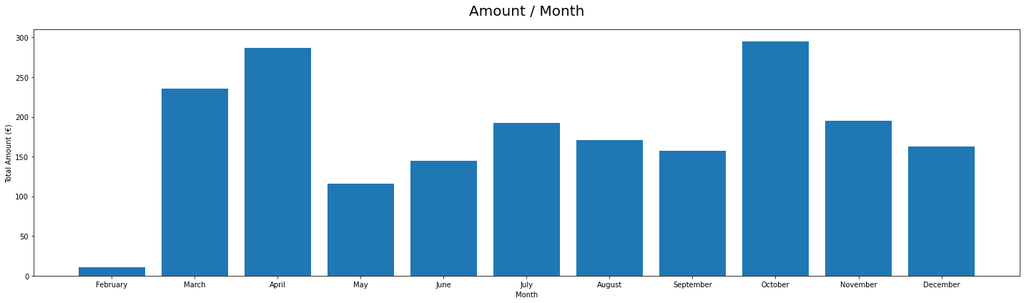

```python
title_config = {'pad': 20, 'size': 20}
fig, ax = plt.subplots(figsize=(20, 6))
months_names = tickets_summary_df.sort_values('ticket_date').month.unique()
df = tickets_summary_df.groupby('month').agg({'total_ticket': 'sum',
                                               'ticket_date': 'min'}).sort_values('ticket_date').reset_index()
ax.set_title('Amount / Month', **title_config);
ax.bar(x=range(len(df)), height=df.total_ticket)
ax.set(xticks=range(len(df)), xticklabels=months_names, xlabel='Month', ylabel='Total Amount (€)')
fig.tight_layout()
```

¿Mis visitas semanales son regulares, es decir, voy siempre el mismo número de veces por semana? **No**.

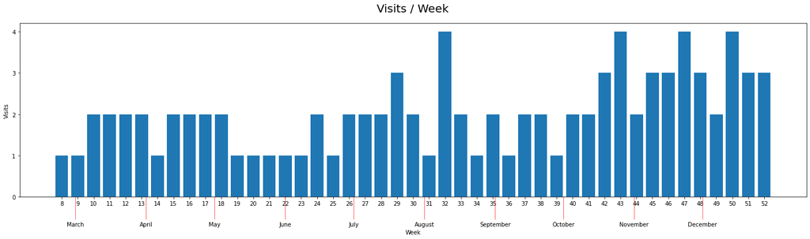

```python
fig, ax = plt.subplots(figsize=(20, 6))
tmp = [datetime(2020, i, 1).strftime('%W-%w').split('-') for i in range(3, 13)]
start_month_week = [int(x[0]) + ((int(x[1])-1)%7)/7 + 1e-3 for x in tmp]  # Add 1e-3 to avoid label overlaping. I know ...
df = tickets_summary_df.groupby('week').agg({'total_ticket': 'count'}).reset_index()
ax.set_title('Visits / Week', **title_config)
ax.bar(x=df.week, height=df.total_ticket)
ax.set_xticks(start_month_week, minor=True)
ax.xaxis.set_minor_formatter(plt.FuncFormatter(lambda _,n: months_names[n + 1]))
ax.set_xticks(range(df.week.min(), df.week.max() + 1))
ax.tick_params(which='minor', length=40, color='r')
ax.set(yticks=range(5), xlabel='Week', ylabel='Visits')
fig.tight_layout()
```

¿Cuál es el día de la semana que más voy a comprar? **El martes**.

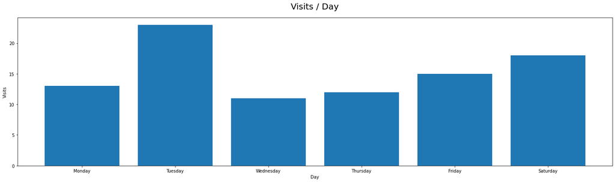

```python
fig, ax = plt.subplots(figsize=(20, 6))
df = tickets_summary_df.groupby('day_of_week').agg({'total_ticket': 'count'}).sort_values('day_of_week').reset_index()
ax.set_title('Visits / Day', **title_config)
ax.bar(x=df.day_of_week, height=df.total_ticket)
ax.set(xlabel='Day', ylabel='Visits',
       xticks=range(len(df)), xticklabels=tickets_summary_df.sort_values('day_of_week').day.unique())
fig.tight_layout()
```

### Procesado de datos

Aunque hemos podido extraer información bastante interesante, no es suficiente para cumplir con los objetivos planteados. Para ello vamos a necesitar ir un paso más allá y obtener los datos contenidos en los tickets descargados. Hay que recordar que los tickets están en formato imagen (*JPG*) y, por tanto, no es posible extraer dichos datos directamente. Para extraer esta información, necesitaremos pasar por varias fases de procesado:

1. Extracción del texto contenido en las imágenes.
2. Estructuración del texto.
3. Extracción de la información relevante.

#### Extracción del texto contenido en las imágenes

Para esta fase será necesario hacer uso de alguna tecnología [*OCR*](https://en.wikipedia.org/wiki/Optical_character_recognition). Existen multitud de opciones que podríamos usar para realizar esta tarea. Me he decantado por el uso de la *Cloud Vision API* para *Python* englobada en los servicios que ofrece [*Google Cloud*](https://cloud.google.com/). No voy a entrar en detalle de como configurar el servicio para poder usarlo, pero si hay algún lector interesado puede buscar más información [aquí](https://cloud.google.com/vision/docs). Las razones para elegir esta opción por encima de las demás son, entre otras:

- **Fiabilidad:** Todos conocemos la calidad de los productos que ofrece *Google*.
- **Simplicidad:**. El uso de la *API* es muy transparente para el usuario. Con muy pocas líneas de código (como veremos en un rato) tenemos acceso a herramientas muy potentes.
- **Coste:** Es un servicio muy asequible para las capacidades que ofrece. Además, oferta un periodo de prueba de 90 días del que yo me he aprovechado para la realización de este proyecto.

¡Bueno, hora de meterse en harina!

Vamos a empezar definiendo algunas constantes que controlarán el comportamiento del script encargado del tratamiento de las imágenes:

```python
VISION_OUTPUT_DIR = '.tickets_vision/'
VISION_AUTH_FILE = '.auth/key.json'
```

Si has consultado el [link](https://cloud.google.com/vision/docs) de la documentación, deciros que la constante `VISION_AUTH_FILE` indica el directorio donde está almacenado el archivo que contiene la clave necesaria para poder utilizar la [API (Application Programming Interface)](https://en.wikipedia.org/wiki/API) de *Google*. Si no has ojeado la documentación no pasa nada, puedes seguir leyendo 😉.

Ahora creamos la carpeta donde se almacenarán los archivos de salida si no existiera:

```python
if not os.path.isdir(VISION_OUTPUT_DIR):
    os.mkdir(VISION_OUTPUT_DIR)
```

Importamos las librerías necesarias:

```python
import io
import glob
import json
from google.cloud import vision
```

Como ya mencionamos anteriormente el uso de la *API* de *Google* es muy sencillo. A continuación, podéis ver la función que se encarga de extraer el texto de cada imagen ¡solamente seis líneas!:

```python
def detect_text(client, image_path):
    """Detects text in the file."""
    with io.open(image_path, 'rb') as image_file:  # Open image file
        content = image_file.read()  # Read image content
    response = client.document_text_detection(image=vision.Image(content=content))  # Call API
    return response.text_annotations  # Return annotations
```

Lo único que necesitamos ahora es usar función `detect_text` en cada una de las imágenes descargadas y almacenar el resultado para su posterior procesado. El fragmento de código responsable de esta tarea sería el siguiente:

```python
print('Creating API client: ', end='')
client = vision.ImageAnnotatorClient.from_service_account_json(VISION_AUTH_FILE) # Create client from JSON auth file.
print('Done!')

progress = ProgressBar(len(tickets_summary_df), 10, task='Processing tickets')

for filename in glob.glob(os.path.join(TICKETS_OUTPUT_DIR, '*.jpg')):
    ticket_id = os.path.basename(filename).split('.')[0]
    texts = detect_text(client, filename)
    data = []
    for text in texts:
        vertices = ([(vertex.x, vertex.y) for vertex in text.bounding_poly.vertices])
        data.append({'text': text.description, 'vertices': vertices})  #  Only relevant info is stored
    # Save data into JSON format
    with open(os.path.join(VISION_OUTPUT_DIR, os.path.basename(filename).split('.')[0] + '.json'), 'w') as outfile:
        json.dump(data, outfile)
    progress += 1
    progress.show()
```

```
Creating API client: Done!
Processing tickets: |====================| Done!
```

La *API* de *Google* devuelve un montón de información sobre los textos encontrados en cada imagen (consultar la documentación para más [info](https://cloud.google.com/vision/docs)). Para cubrir nuestras necesidades no necesitamos toda esa información. Solo dos características nos interesan:

- Los textos encontrados (obviamente 😄).
- La posición donde se encontraron dichos textos (explicación: próximamente).

Esta información se ha almacenado en formato JSON (muy útil para trabajar con datos semiestructurados). A continuación, mostramos un fragmento de uno de los archivos de salida para que os hagáis una idea de la pinta que tienen:

```python
from pprint import pprint

with open(os.path.join(VISION_OUTPUT_DIR, '{}.json'.format(sample_ticket_id)), 'r') as f:
    sample_ticket = json.load(f)[1:]

pprint(sample_ticket[40:50])
```

```
[{'text': 'SEMI', 'vertices': [[64, 155], [86, 155], [86, 167], [64, 167]]},
 {'text': '250', 'vertices': [[87, 156], [105, 156], [105, 167], [87, 167]]},
 {'text': 'ESPINACAS', 'vertices': [[2, 169], [60, 169], [60, 179], [2, 179]]},
 {'text': 'C', 'vertices': [[68, 169], [71, 169], [71, 179], [68, 179]]},
 {'text': '/', 'vertices': [[77, 169], [78, 169], [78, 179], [77, 179]]},
 {'text': 'GARBANZS',
  'vertices': [[80, 169], [132, 169], [132, 179], [80, 179]]},
 {'text': 'PECHUGA', 'vertices': [[3, 181], [47, 181], [47, 191], [3, 191]]},
 {'text': 'POLLO', 'vertices': [[55, 181], [86, 181], [86, 191], [55, 191]]},
 {'text': 'SABORES', 'vertices': [[3, 193], [47, 193], [47, 203], [3, 203]]},
 {'text': 'ALI', 'vertices': [[55, 193], [73, 193], [73, 203], [55, 203]]}]
```

Hablando en términos de estructuras de datos de *Python* básicamente es un [lista](https://www.w3schools.com/python/python_lists.asp) de [diccionarios](https://www.w3schools.com/python/python_dictionaries.asp), donde cada diccionario contiene dos entradas:

- **text:** el texto.
- **vertices:** los vértices de la *bounding box* (cajita que contiene al texto 📦) en el siguiente orden: sup-izq, sup-der, inf-der y inf-izq.

Ahora disponemos de dos formas de representar la misma información: una en forma de imagen (👎) y otra en forma de palabras y cajitas (👍). Para se vea más claramente las diferencias/similitudes entre las dos, vamos a representar ambas para compararlas. Definiremos un par de funciones que nos ayudarán a representar gráficamente todas esas palabras. La primera, `plot_word`, plotea cada palabra con su *bounding box*. La segunda, `plot_ticket`, únicamente aplica la función anterior a todas las palabras extraídas de un determinado ticket.

```python
from matplotlib.patches import Rectangle


def plot_word(word, color, ax, size=8, axhline=False):

    """Plots text with its bounding box"""

    ax.text(*word['vertices'][0], word['text'], va='top', ha='left', size=size)  # Plot text
    w = word['vertices'][1][0] - word['vertices'][0][0]
    h = word['vertices'][-1][1] - word['vertices'][0][1]
    rect = Rectangle(word['vertices'][0], w, h, linewidth=1, facecolor=color, alpha=0.3)  # Create bounding box
    if axhline:
        ax.axhline(y=word['vertices'][0][1] + h/2, color=color, alpha=0.6)  # Plot horizotal line
    ax.add_patch(rect)  # Plot box


def plot_ticket(ticket_words, width, height, ax):

    """Plots all words of one ticket"""

    colors = ['blue', 'red', 'green', 'yellow', 'grey', 'orange']

    for word in ticket_words:
        color = np.random.choice(colors, 1)[0]
        plot_word(word, color, ax)

    ax.set(xlim=(0, width), ylim=(0, height), xticks=(), yticks=())
    ax.invert_yaxis()
```

Veamos las diferencias:

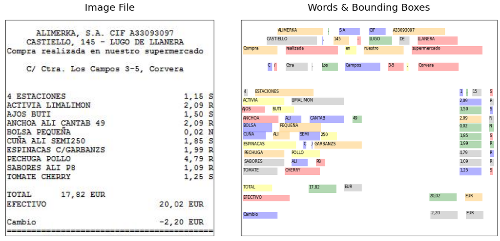

```python
im = imageio.imread(os.path.join(TICKETS_OUTPUT_DIR, '{}.jpg'.format(sample_ticket_id)))
fig, axs = plt.subplots(1, 2, figsize=(15, 7))
axs[0].set_title('Image File', **title_config)
axs[0].imshow(im[0:290, ::], cmap='gray', vmin=0, vmax=255)
axs[0].set(xticks=(), yticks=())
axs[1].set_title('Words & Bounding Boxes', **title_config)
plot_ticket(ticket_words=sample_ticket[:84], width=280, height=300, ax=axs[1])
fig.tight_layout()
```

Los resultados de la extracción del texto son muy buenos aunque se pueden observar algunos problemillas:

- En la primera compra ("4 ESTACIONES", que conste que es una ensalada y no una pizza 😄) el precio no ha sido identificado como una única palabra, lo que si sucede con el resto de las líneas del ticket.
- En la línea "CUÑA ALI SEMI250" el sistema *OCR* separa la palabra "SEMI250" en dos: "SEMI" y "250".
- La línea donde figura el total no está perfectamente alineada y esta desviada ligeramente hacía arriba.

Todos esos pequeños problemas los trataremos de solucionar en las siguientes secciones. Lo más importante ahora es que hemos pasado de un problema de gestión de **imágenes** (muy complicado) a un problema de gestión de **textos** (menos complicado).

#### Estructuración del texto

En este punto tenemos un montón de palabras sueltas desperdigadas por el espacio (textos y cajitas). Un ticket, como cualquier documento escrito, tiene lógica cuando sus palabras están organizadas de forma coherente y no flotando por ahí. La forma de organizar estas palabras son las líneas. Es fácil leer una línea, solo tenemos que recorrer las palabras en un orden específico (de arriba a abajo y de izquierda a derecha en el caso del castellano). El objetivo de este apartado es precisamente ese, agrupar esas "palabras flotantes" en líneas.

Como conocemos las posiciones de las cajas que contienen los textos (de ahí la importancia de guardar esos valores) podemos establecer un criterio muy sencillo pero efectivo para saber si dos palabras pertenecen a la misma línea que es el siguiente: dos palabras pertenecen a la misma línea si la distancia vertical entre sus puntos medios es menor que cierto valor prefijado al que llamaremos umbral. Vamos a ilustrar el concepto con un ejemplo muy sencillo:

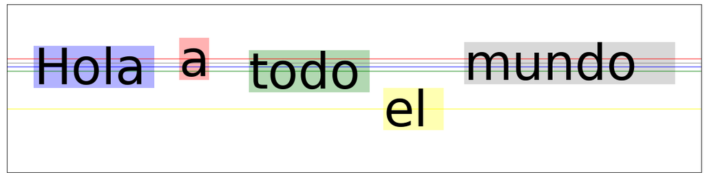

```python
def make_vertices(x, y, width, height):
    """Create the vertices of a bounding box with: x, y, width and height values"""
    return [[x, y], [x + width, y], [x + width, y - height], [x, y - height]]


letter_width = 5.6
letter_height = 1
colors = ['blue', 'red', 'green', 'yellow', 'gray']

# Some fake data simulating JSON files
text_data = [{'text': 'Hola', 'vertices': make_vertices(0 , 4, letter_width * 4, letter_height)},
        {'text': 'a', 'vertices': make_vertices(27 , 4.2, letter_width * 1, letter_height)},
        {'text': 'todo', 'vertices': make_vertices(40 , 3.9, letter_width * 4, letter_height)},
        {'text': 'el', 'vertices': make_vertices(65 , 3, letter_width * 2, letter_height)},
        {'text': 'mundo', 'vertices': make_vertices(80 , 4.1, letter_width * 7, letter_height)},
       ]

fig, ax = plt.subplots(figsize=(20, 5))
ax.set(xlim=(-5, 124), ylim=(1, 5), xticks=(), yticks=())

for color, word in zip(colors, text_data):
    plot_word(word, color, ax, size=80, axhline=True)
```

En este ejemplo las palabras: *"Hola"*, *"a"*, *"todo"*, *"mundo"* pertenecerían a una misma línea (sus centros están muy próximos) mientras que la palabra *"el"* pertenecería a una línea distinta. Entendido el concepto, será muy fácil comprender el proceso que transformará nuestra nube de palabras en un conjunto de líneas.

Antes de pasar a ver el código, vamos a estudiar la importancia de elegir un buen *threshold* (umbral). Usaremos una función *helper* para mostrar visualmente los resultados. Esta nueva función está basada en `plot_ticket` (ver apartado anterior) modificada levemente para mostrar las líneas obtenidas (líneas horizontales grises) en función del *threshold*.

```python
def plot_ticket_with_lines(ticket_words, threshold, width, height, ax):

    """Plots all words of one ticket with lines"""

    colors = ['blue', 'red', 'green', 'yellow', 'grey', 'orange']
    last_line = 0
    ticket_words = sorted(ticket_words, key=lambda x: x['vertices'][0][1], reverse=False)  # From top to bottom (y-axis)

    for word in ticket_words:
        color = np.random.choice(colors, 1)[0]
        plot_word(word, color, ax)
        this_line = (word['vertices'][-1][1] + word['vertices'][0][1])/2
        if (this_line - last_line) > threshold:
            ax.axhline(y=this_line, linewidth=0.5, color='black', alpha=0.7)
            last_line = this_line

    ax.set(xlim=(0, width), ylim=(0, height), xticks=(), yticks=())
    ax.invert_yaxis()
```

Veamos ahora como varían los resultados al usar distintos *thresholds*:

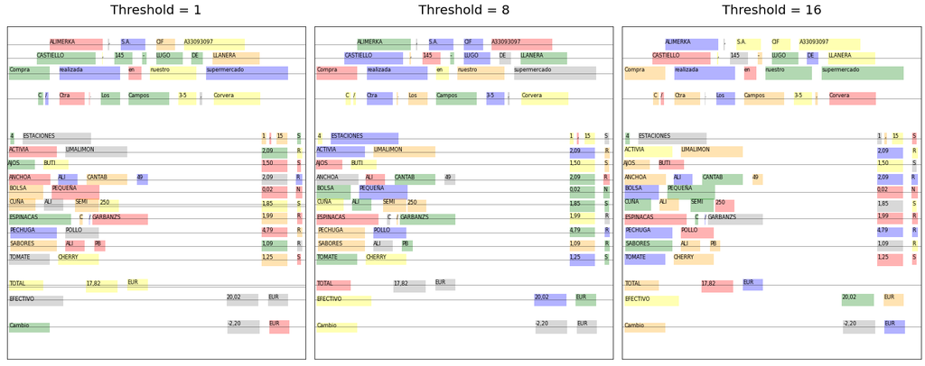

```python
fig, axs = plt.subplots(1, 3, figsize=(20, 8))

for n, threshold in enumerate([1, 8, 16]):
    axs[n].set_title('Threshold = {}'.format(threshold), **title_config)
    plot_ticket_with_lines(ticket_words=sample_ticket[:84], threshold=threshold, width=280, height=300, ax=axs[n])

fig.tight_layout()
```

**De izquierda a derecha.** Un umbral demasiado pequeño hace que se generen más líneas de las que realmente existen provocando pérdidas de información. Un umbral adecuado encuentra el número de líneas correcto. Un umbral demasiado grande provoca que se encuentren menos líneas de las que existen haciendo que las palabras de varias de ellas se unan en una sola y, por lo tanto, que se entremezcle información.

Pasemos ahora a ver el código encargado de transformar las nubes de palabras (*JSON*) en archivos de texto plano. Primeramente, definiremos algunas constantes que controlarán el funcionamiento del código:

```python
TEXT_OUTPUT_DIR = '.tickets_text/'
THRESHOLD = 8
```

El valor del `THRESHOLD` no se ha elegido al azar y para su elección se ha considerado tanto el tamaño de la fuente como la distancia promedio entre líneas de los archivos de imagen originales.

Creamos la carpeta para los archivos de salida si no exisitiera:

```python
if not os.path.isdir(TEXT_OUTPUT_DIR):
    os.mkdir(TEXT_OUTPUT_DIR)
```

Finalmente, este sería el código encargado de realizar la dura tarea:

```python
progress = ProgressBar(len(tickets_summary_df), 10, task='Processing JSON files')

for filename in glob.glob(os.path.join(VISION_OUTPUT_DIR, '*.json')):

    ticket_id = os.path.basename(filename).split('.')[0]

    last_line = 0  # Current line possition
    lines = []  # All lines
    line = []  # Current line

    # Load JSON  data. First record is ignored cause is the whole text in ticket (unstructured).
    with open(filename, 'r') as f:
        ticket_words = json.load(f)[1:]

    # Sort words from top to bottom (y-axis)
    ticket_words = sorted(ticket_words, key=lambda x: x['vertices'][0][1], reverse=False)

    for word in ticket_words:  # For each word
        this_line = (word['vertices'][-1][1] + word['vertices'][0][1]) / 2  # Calculate the new word middle point
        if (this_line - last_line) > THRESHOLD:  # If difference is greater than THRESHOLD there is a new line ...
            if len(line) > 0: # If there are data in old line ...
                # Stored it but first sort words from left to right (x-axis)
                lines.append([token for (token, pos) in sorted(line, key=lambda x: x[1], reverse=False)])
                line = []  # Empty line contents
            last_line = this_line # Store current line position
        # Add word to line
        line.append((word['text'], word['vertices'][0][0]))  # (text, xpos)

    # Update progress bar
    progress += 1
    progress.show()

    # Save lines to txt file
    with open(os.path.join(TEXT_OUTPUT_DIR, '{}.txt'.format(ticket_id)), 'w', encoding="utf-8") as outfile:
        outfile.writelines([' '.join(line) + '\n' for line in lines])
```

```
Processing JSON files: |====================| Done!
```

Para nuestro ticket de referencia la salida sería la siguiente (solamente la cabecera):

```python
with open(os.path.join(TEXT_OUTPUT_DIR, '{}.txt'.format(sample_ticket_id)), 'r', encoding="utf-8") as f:
    ticket_data = f.read()

print(ticket_data[:425])
```

```
ALIMERKA , S.A. CIF A33093097
CASTIELLO , 145 - LUGO DE LLANERA
Compra realizada en nuestro supermercado
C / Ctra . Los Campos 3-5 , Corvera
4 ESTACIONES 1 , 15 S
ACTIVIA LIMALIMON 2,09 R
AJOS BUTI 1,50 S
ANCHOA ALI CANTAB 49 2,09 R
BOLSA PEQUEÑA 0,02 N
CUÑA ALI SEMI 250 1,85 S
ESPINACAS C / GARBANZS 1,99 R
PECHUGA POLLO 4,79 R
SABORES ALI PB 1,09 R
TOMATE CHERRY 1,25 S
TOTAL 17,82 EUR
EFECTIVO 20,02 EUR
Cambio -2,20 EUR
```

Ya tenemos nuestros tickets en texto plano y estructurados en líneas. Ahora es el momento de "entender" lo que está escrito. De eso trata el siguiente apartado.

#### Extracción de la información relevante

Esta será la última fase de la extracción de los datos. Al final de este apartado los datos estarán listos para su explotación (previa validación, claro). Pero antes de ponerse manos a la obra, lo primero que tenemos que hacer es entender a nuestro "enemigo".

*Fisionomia de un ticket*

Cada ticket se puede dividir en tres zonas (ver imagen):

- Zona de cabecera (roja).
- Zona de compras (amarillo).
- Zona de cola (azul).

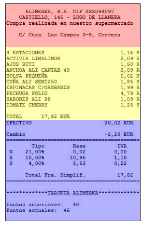

```python
im = imageio.imread(os.path.join(TICKETS_OUTPUT_DIR, '{}.jpg'.format(sample_ticket_id)))
height, width, _ = im.shape
fig, ax = plt.subplots(figsize=(5, 10))
ax.imshow(im[:450, ::], cmap='gray', vmin=0, vmax=255)
heights = [90, 150, height - 90 - 150]
positions = [0, 90, 90 + 150]
for p, h, c in zip(positions, heights, ['red', 'yellow', 'blue']):
    rect = Rectangle((0, p), width, h, linewidth=1, facecolor=c, alpha=0.3)
    ax.add_patch(rect)
ax.set(xticks=(), yticks=());
```

La parte interesante (para nuestros objetivos) es la “Zona de compras” (amarillo). La "Zona de compras" está formada por líneas (de ahí la importancia del apartado anterior). Existen varios tipos de líneas en función del número de productos adquiridos, descuentos aplicados, tipo de producto, etc. Además de estas, existe una línea especial que solo aparece una vez y que delimita el final de la "Zona de compras" (la llamaremos **Línea total**). A continuación, se muestra una lista exhaustiva de todos los tipos de línea que nos podemos encontrar:

- **Línea producto:** este tipo de líneas puede ser de dos tipos:
  - **Línea simple:** aparecen cuando únicamente compramos una unidad del producto especificado.
  - **Línea múltiple:** aparecen cuando o bien compramos varias unidades de un producto o cuando este se compra al peso (fruta, por ejemplo). Este tipo de líneas siempre van acompañadas de las llamadas **Línea cuenta**.
- **Línea cuenta:** siempre aparecen a continuación de una **Línea múltiple** y su función es registrar el número/peso de los productos adquiridos.
- **Línea descuento:** estas siempre aparecen asociadas a una **Línea producto** (simple o múltiple). Pueden existir una o varias por producto. Como su nombre indica, registra el descuento aplicado sobre un producto.
- **Línea total:** aparece solo una vez y delimita la “Zona de compras”. En ella figura la cantidad total a pagar.

Veamos algunos ejemplos:

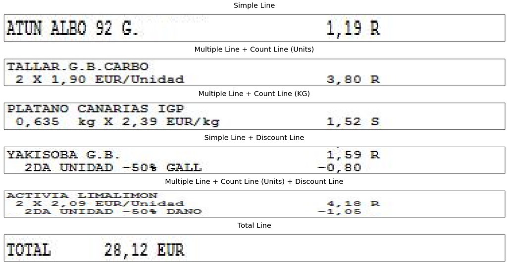

```python
ims = [imageio.imread(os.path.join(TICKETS_OUTPUT_DIR, '{}.jpg'.format('000258'))),
       imageio.imread(os.path.join(TICKETS_OUTPUT_DIR, '{}.jpg'.format('000353')))]
titles = ['Simple Line', 'Multiple Line + Count Line (Units)', 'Multiple Line + Count Line (KG)',
          'Simple Line + Discount Line', 'Multiple Line + Count Line (Units) + Discount Line', 'Total Line']
limits = [(132, 145), (240, 265), (145, 170), (300, 325), (95, 135), (335, 350)]
images = [0, 0, 1, 0, 0, 0]

n = len(titles)
fig, axs = plt.subplots(n, 1, figsize=(20, n*1.75))

for i, (title, limit, im) in enumerate(zip(titles, limits, images)):
    axs[i].set_title(title, **title_config)
    axs[i].imshow(ims[im][limit[0]:limit[1], ::], cmap='gray', vmin=0, vmax=255, aspect='auto')
    axs[i].set(xticks=(), yticks=())

plt.tight_layout()
```

Como se puede ver cada tipo de línea tiene una estructura característica. Para un humano es muy sencillo determinar el tipo de línea y las relaciones entre ellas (somos muy buenos encontrando patrones 😎) pero no es tan fácil hacerlo de forma automática. ¡Don't worry! las [expresiones regulares](https://en.wikipedia.org/wiki/Regular_expression) acuden al rescate.

Nos aprovecharemos de la estructura implícita de las líneas y de la potencia de las expresiones regulares para extraer la información que contienen. Una cosa importante a tener en cuenta es que como vimos en un apartado anterior, la transcripción de imagen a texto aunque muy buena, contiene pequeños errores. Esto nos obliga a utilizar expresiones regulares suficientemente flexibles para que tengan en cuenta estos problemillas. Las expresiones regulares utilizadas para cada tipo de línea se pueden consultar en el código fuente que podréis ver un poco más adelante.

Antes de nada, y como ya es costumbre, vamos a definir algunas constantes:

```python
CSV_OUTPUT_DIR = '.tickets_csv/'
```

Creamos la carpeta para los archivos de salida si no exisitiera:

```python
if not os.path.isdir(CSV_OUTPUT_DIR):
    os.mkdir(CSV_OUTPUT_DIR)
```

Definiremos dos funciones auxiliares para descomponer las tareas y hacer el código más legible. La primera, `parse_number`, es muy simple y transforma las cadenas de texto que representan números en números de verdad. Por ejemplo, las cadenas: *"2"*, *"1,8"*, *"1, 00"* o *"1 , 2"* se transformarían respectivamente en: *2.0*, *1.8*, *1.0* y *1.2*.

```python
def parse_number(number):
    """Parses  'numbers' to real numbers"""
    return float(str(number).replace(',', '.').replace(' ', ''))
```

La segunda, `parse_ticket`, se encarga de transformar los tickets en formato texto (lista de cadenas de texto) en un listado de diccionarios. Donde cada diccionario almacenará la información de la venta de cada producto:

- **ticket_id:** identificador único del ticket.
- **product_name:** nombre del producto.
- **iva:** tipo de iva aplicado.
- **units:** unidad de medida del producto KG/UNIDADES.
- **count:** número de unidades o peso.
- **unit_price:** precio por unidad o por KG.
- **total_price:** coste total del producto. Si todo es correcto debería ser igual a **count** * **unit_price**.
- **discount_name:** nombre o nombres de los descuentos aplicados separados por comas.
- **discount:** importe del descuento.
- **total_ticket:** suma total del ticket al que pertenece la venta.

A continuación, se muestra el código de la función. Esta ampliamente comentado para aquellos que tengan curiosidad por los detalles de la implementación:

```python
def parse_ticket(ticket, ticket_id):

    """Transforms a ticket (list of lines) into a list of dictations with the information of the purchases"""

    # Regular expressions (re). Same name conventions as exposed in examples
    simple_line = r'^(?P<product_name>.*)\s+(?P<unit_price>\d+\s*,\s*\d{2})\s?(?P<iva>[0-9A-Z])?$'
    count_line = r'^(?P<count>\d+(\s*,\s*\d+)?)\s+(KG\s+)?X\s+(?P<unit_price>\d+\s*,\s*\d{2})\s+EUR \/ ' + \
                 r'(?P<units>(UNIDAD|KG))\s+(?P<total_price>\d+\s*,\s*\d{2})\s?(?P<iva>[0-9A-Z])?$'
    discount_line = r'^(?P<discount_name>.*)\s+-(?P<discount>\d+\s*,\s*\d{2})$'
    total_line = r'^TOTAL\s+[^0-9]*(?P<total>\d+\s*,\s*\d{2})\s+EUR$'

    # Compiled regular expressions are stored in a dictionary for convenience
    re_dict = {'simple_line': re.compile(simple_line),
               'count_line': re.compile(count_line),
               'discount_line': re.compile(discount_line),
               'total_line': re.compile(total_line)}

    # In all tickets the top four lines contains supermarket info. No relevant for us
    skip = 4  # Skip loc info

    purchases = []  # List for all purchases
    purchase = {}  # One purchase

    for ticket_line in ticket[skip:]:  # For each line (Skip first 4 lines)

        current_line = ticket_line.upper().strip()  # String cleaning
        # All the r.e. are applied to line to find out the line type.
        searches = {k: re_dict[k].search(current_line) for k in re_dict}
        # The order of evaluation is relevant!
        if searches['count_line']:  # Is a count line. Update purchase info.
            purchase.update(searches['count_line'].groupdict())

        elif searches['discount_line']:  # Is a discount line. There are two possibilities now:

            if 'discount' in purchase:  # Previous discount exists.
                # Acceptable solution only if u are not interested in individual discounts.
                # TODO implement a better approach
                new_discount = searches['discount_line'].groupdict()  # Get discount info
                # New discount string is added to existing discount string separated by a comma
                purchase['discount_name'] += ', ' + new_discount['discount_name']
                # Increment discount amount
                purchase['discount'] = parse_number(purchase['discount']) + parse_number(
                    new_discount['discount'])  # No problem if discount is already a number
            else:  # There is not previous discount.
                purchase.update(searches['discount_line'].groupdict())  # Update purchase info

        elif searches['simple_line']:  # Is a simple line so all previous stored info if exists, refers to another purchase
            if len(purchase):  # If there is a info from the previous purchase
                purchases.append(purchase)  # Save it in purchases list
            # Create a new purchase
            purchase = searches['simple_line'].groupdict()
            purchase['count'] = 1
            purchase['total_price'] = purchase['unit_price']
            purchase['units'] = 'UNIDAD'

        elif searches['total_line']:  # Is a total line.
            # Store total ticket cost and break the loop. Almost all done.
            total_ticket = searches['total_line'].group('total')
            break

        else:  # If is not a "another thing" is a multiple line. All previous stored info if exists, refers to another purcha
            if len(purchase):  # If there is a info from the previous purchase
                purchases.append(purchase)  # Save it in purchases list
            # Create a new purchase
            purchase = {'product_name': current_line}

    purchases.append(purchase)  # Store last purchase created
    # Add to all purchases total cost and ticket id info
    for purchase in purchases:
        purchase['total_ticket'] = total_ticket
        purchase['ticket_id'] = ticket_id

        # Parse 'number' attribute to number attribute
        for att in ['unit_price', 'count', 'total_price', 'discount', 'total_ticket']:
            if att in purchase:  # Note that discount is not present in all records
                purchase[att] = parse_number(purchase[att])

    return purchases
```

Para terminar se aplica la función `parse_ticket` a todos los tickets y se almacenan los resultados en archivos *CSV*. Este sería el código:

```python
progress = ProgressBar(len(tickets_summary_df), 10, task='Processing text files')

fieldnames = ['ticket_id', 'product_name', 'iva', 'units', 'count', 'unit_price', 'total_price', 'discount_name',
              'discount', 'total_ticket']

with open(os.path.join(CSV_OUTPUT_DIR, 'tickets_detail.csv'), 'w', encoding='utf-8') as summary_file:
    summary_writer = csv.DictWriter(summary_file, fieldnames=fieldnames, dialect='custom')
    summary_writer.writeheader()

    for filename in glob.glob(os.path.join(TEXT_OUTPUT_DIR, '*.txt')):

        ticket_id = os.path.basename(filename).split('.')[0]
        with open(filename, 'r', encoding="utf-8") as f:
            ticket_data = f.readlines()

        parsed_ticket = parse_ticket(ticket_data, ticket_id)

        # Save individual files
        with open(os.path.join(CSV_OUTPUT_DIR, os.path.basename(filename).split('.')[0] + '.csv'), 'w',
                  encoding="utf-8") as outfile:
            writer = csv.DictWriter(outfile, fieldnames=fieldnames, dialect='custom')
            writer.writeheader()
            writer.writerows(parsed_ticket)


        summary_writer.writerows(parsed_ticket)
        progress += 1
        progress.show()
```

```
Processing text files: |====================| Done!
```

Este sería el aspecto que tendría ahora un ticket:

```python
sample_ticket_df = pd.read_csv(os.path.join(CSV_OUTPUT_DIR, '{}.csv'.format(sample_ticket_id)), sep=',', decimal='.')
display(sample_ticket_df)
```

|  | ticket_id | product_name | iva | units | count | unit_price | total_price | discount_name | discount | total_ticket |
| --- | --- | --- | --- | --- | --- | --- | --- | --- | --- | --- |
| 0 | 7347 | 4 ESTACIONES | S | UNIDAD | 1.0 | 1.15 | 1.15 | NaN | NaN | 17.82 |
| 1 | 7347 | ACTIVIA LIMALIMON | R | UNIDAD | 1.0 | 2.09 | 2.09 | NaN | NaN | 17.82 |
| 2 | 7347 | AJOS BUTI | S | UNIDAD | 1.0 | 1.50 | 1.50 | NaN | NaN | 17.82 |
| 3 | 7347 | ANCHOA ALI CANTAB 49 | R | UNIDAD | 1.0 | 2.09 | 2.09 | NaN | NaN | 17.82 |
| 4 | 7347 | BOLSA PEQUEÑA | N | UNIDAD | 1.0 | 0.02 | 0.02 | NaN | NaN | 17.82 |
| 5 | 7347 | CUÑA ALI SEMI 250 | S | UNIDAD | 1.0 | 1.85 | 1.85 | NaN | NaN | 17.82 |
| 6 | 7347 | ESPINACAS C / GARBANZS | R | UNIDAD | 1.0 | 1.99 | 1.99 | NaN | NaN | 17.82 |
| 7 | 7347 | PECHUGA POLLO | R | UNIDAD | 1.0 | 4.79 | 4.79 | NaN | NaN | 17.82 |
| 8 | 7347 | SABORES ALI PB | R | UNIDAD | 1.0 | 1.09 | 1.09 | NaN | NaN | 17.82 |
| 9 | 7347 | TOMATE CHERRY | S | UNIDAD | 1.0 | 1.25 | 1.25 | NaN | NaN | 17.82 |

Este era el último de los pasos necesarios para la extracción de los datos. Ha sido un camino largo pero muy interesante. Hemos partido de tener casi toda la información en archivos de imagen (datos no estructurados) donde la información no era explotable, a tenerlos en un formato totalmente estructurado, donde se podrá sacar partido de todos los datos que contienen. Aún podríamos extraer mucha más información, pero eso lo dejaremos para trabajos futuros. Por ahora, con lo que tenemos es suficiente.

## Validación de los datos

Igual de importante que la captura de datos es verificar que estos son veraces. De nada sirve tener un montón de información si no nos podemos fiar de ella. A mi parecer, la validación de los datos es uno de los aspectos más importantes del proceso del análisis de datos y en muchos casos no se le da importancia que se merece. En nuestro caso se podría llegar a hacer una validación manual ya que no hay muchos registros, pero esto no es posible en la mayoría de los casos. Aunque posible, es aburrido, tedioso y no escala bien por lo que nosotros utilizaremos una validación automática. Para validar los datos usaremos una técnica similar a los [test unitarios](https://en.wikipedia.org/wiki/Unit_testing) que se usan en el mundo de la programación. Cuatro test serán los encargados de dar el visto bueno a los datos y serán los siguientes:

- **Los tickets han sido “parseados” de forma correcta:** se comprobará que todos los campos que debieran tener valor, efectivamente lo tienen. Los campos que se comprobarán son: `ticket_id`, `product_name`, `count`, `unit_price`, `total_price`.
- **Consistencia de los registros:** se comprobará que cada línea es consistente. Dicho de otra manera, que se cumpla que: `count` * `unit_price` = `total_price`.
- **Congruencia de los tickets:** se comprobará que la suma de todos los costes de los productos (deduciendo los descuentos) coincide con el total de ticket (`total_ticket`).
- **Validación de los costes de los tickets:** se comprobará que el coste total del ticket coincide con el almacenado en la tabla resumen.

**Nota:** Estos test garantizan la calidad de los datos **SOLO** en los aspectos que nos parecen cruciales. Otros aspectos no han sido validados como por ejemplo, que todos los productos tengan tipo de *IVA* o que no haya errores en los nombres de los productos (⚠️ninguna de las dos se cumple⚠️). Detectar esos problemas de forma automática queda fuera del ámbito de este trabajo (aunque podría hacerse, por supuesto 😎).

Lo primero será cargar los datos creados en los apartados anteriores:

```python
ticket_detail_df = pd.read_csv(os.path.join(CSV_OUTPUT_DIR, 'tickets_detail.csv'), sep=',', decimal='.')
display(ticket_detail_df.sort_values('ticket_id').head(5))
```

|  | ticket_id | product_name | iva | units | count | unit_price | total_price | discount_name | discount | total_ticket |
| --- | --- | --- | --- | --- | --- | --- | --- | --- | --- | --- |
| 0 | 258 | ACTIVIA LIMALIMON | R | UNIDAD | 2.0 | 2.09 | 4.18 | 2DA UNIDAD -50 % DANO | 1.05 | 28.12 |
| 13 | 258 | YAKISOBA G.B. | B | UNIDAD | 1.0 | 1.59 | 1.59 | 2DA UNIDAD -50 % GALL | 0.80 | 28.12 |
| 12 | 258 | YAKISOBA G.B. | R | UNIDAD | 1.0 | 1.59 | 1.59 | NaN | NaN | 28.12 |
| 11 | 258 | ZUMO D.SIMON 1L | R | UNIDAD | 1.0 | 2.50 | 2.50 | NaN | NaN | 28.12 |
| 9 | 258 | TALLAR.G.B . CARBO | B | UNIDAD | 2.0 | 1.90 | 3.80 | NaN | NaN | 28.12 |

```python
mrkdwn = ''
fact = 'Se han extraido un total de **{sales:d}** compras de productos.'
mrkdwn += fact.format(sales=len(ticket_detail_df))
md(mrkdwn)
```

Se han extraido un total de **1035** compras de productos.

Momento de aplicar los test de validación:

**Test #1: Los tickets han sido "parseados" de forma correcta**

```python
ticket_detail_df[ticket_detail_df[['ticket_id', 'product_name', 'count', 'unit_price', 'total_price']].isnull().any(axis=1)]
```

|  | ticket_id | product_name | iva | units | count | unit_price | total_price | discount_name | discount | total_ticket |
| --- | --- | --- | --- | --- | --- | --- | --- | --- | --- | --- |
| 693 | 6547 | BEBIDA ALMENDROLA 1 , BO R | NaN | NaN | NaN | NaN | NaN | NaN | NaN | 12.21 |

Se ha encontrado un registro que no está parseado de forma correcta. Veamos el ticket de origen para ver que ha podido pasar:

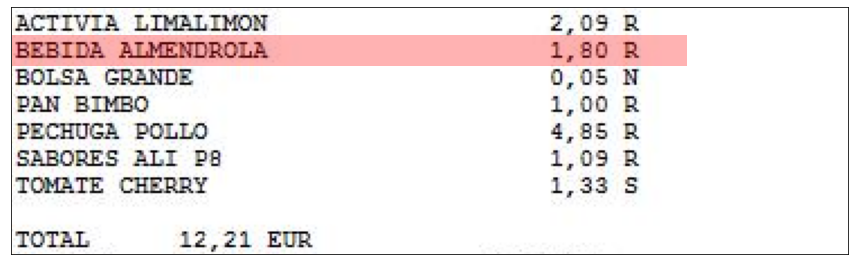

```python
im = imageio.imread(os.path.join(TICKETS_OUTPUT_DIR,'{}.jpg'.format('006547')))
cropped_image = im[95: 205, :, :]
fig, ax = plt.subplots(figsize=(15, 5))
ax.imshow(cropped_image, cmap='gray', vmin=0, vmax=255)
ax.add_patch(Rectangle((0, 12), 300, 14, linewidth=1, facecolor='red', alpha=0.3))
ax.set(xticks=(), yticks=());
```

El problema está claro, el sistema *OCR* ha confundido un **ocho** con una **B** (no vamos a ser muy duros con *Google*, es un error muy razonable). Solucionaremos este pequeño error de forma manual para poder seguir con los demás test:

```python
ticket_detail_df.loc[693] = [6547, 'BEBIDA ALMENDROLA', 'R', 'UNIDAD', 1, 1.80, 1.80, np.nan, np.nan, 12.21]
```

**Test #2: Consistencia de los registros**

```python
calc_total_price = ticket_detail_df['count'] * ticket_detail_df['unit_price']
ticket_detail_df.loc[np.abs(calc_total_price - ticket_detail_df['total_price']) > 1e-2] # 1e-2 is the max precision.
```

|  | ticket_id | product_name | iva | units | count | unit_price | total_price | discount_name | discount | total_ticket |
| --- | --- | --- | --- | --- | --- | --- | --- | --- | --- | --- |
| 270 | 2396 | TOMATE SABROSONA | S | KG | 0.48 | 2.95 | 0.94 | NaN | NaN | 16.07 |

Se ha encontrado un registro inconsistente. Vamos a ver ticket de origen para intentar detectar el error:

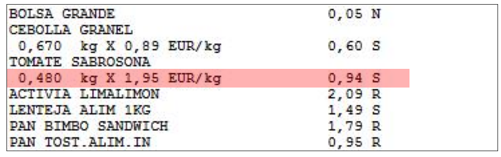

```python
im = imageio.imread(os.path.join(TICKETS_OUTPUT_DIR,'{}.jpg'.format('002396')))
cropped_image = im[95: 205, :, :]
fig, ax = plt.subplots(figsize=(15, 5))
ax.imshow(cropped_image, cmap='gray', vmin=0, vmax=255)
ax.add_patch(Rectangle((0, 48), 300, 14, linewidth=1, facecolor='red', alpha=0.3))
ax.set(xticks=(), yticks=());
```

Esta vez el error cometido es confundir un **uno** con un **dos**. No pasa nada, lo corregimos nuevamente de forma manual:

```python
ticket_detail_df.loc[270, 'unit_price'] = 1.95
```

**Test #3: Congruencia de los tickets**

```python
ticket_agg_df = ticket_detail_df.groupby('ticket_id').agg({'total_price': 'sum',
                                                           'discount': 'sum',
                                                           'total_ticket': 'max'})
ticket_agg_df[np.abs(ticket_agg_df.total_price - ticket_agg_df.discount - ticket_agg_df.total_ticket) > 1e-2]
```

|  | total_price | discount | total_ticket |
| --- | --- | --- | --- |
| ticket_id |  |  |  |

¡Estupendo! no hemos encontrado ningún ticket que no haya pasado el test.

**Test #4: Validación de los costes de los tickets**

```python
ticket_agg_df = ticket_detail_df.groupby('ticket_id').agg({'total_ticket': 'max'}).sort_values(by='ticket_id')
ticket_agg_df[ticket_agg_df.total_ticket.values != tickets_summary_df.sort_values(by='ticket_id').total_ticket.values]
```

|  | total_ticket |
| --- | --- |
| ticket_id |  |

¡Genial! Nuevamente todos los registros han pasado el test.

Un lector perspicaz podría pensar: "Pues vaya 💩 de sistema de extracción de datos si tenemos que andar corrigiendo manualmente los errores". Como responsable de la implementación del sistema yo le respondería lo siguiente:

1. La perfección en el mundo real no es muy frecuente 😎.
2. Estaríamos hablando de un ratio de error de **dos** sobre **mil treinta y cinco** o lo que es lo mismo, más de un **99.8%** de aciertos. Personalmente considero que es un valor suficientemente alto como para considerar la metodología como excelente 👍.

El último paso será guardar los datos con las correcciones:

```python
ticket_detail_df.to_csv(os.path.join(CSV_OUTPUT_DIR, 'tickets_detail_fixed.csv'), index=False, sep=',', decimal='.')
```

Todo listo, en este apartado hemos validado y corregido los datos. Antes de seguir adelante, creo que es importante tener en cuenta los siguientes aspectos:

- No hemos verificado todos los posibles errores que pudieran existir.
- Validar y corregir, aunque en este caso se ha enmarcado a ambos bajo el mismo encabezado por comodidad, son procesos diferentes aunque muy ligados.
- Los procesos de validación y corrección forman parte del proceso cíclico que es un proyecto de *Machine Learning*, por lo que es frecuente que se revisiten y se reformulen durante el ciclo de vida del proyecto.

## Explotación de los datos

Es muy común oír a los cocineros profesionales decir que lo más importante para hacer un plato exquisito es la materia prima. Pues bien, tenemos una excelente materia prima (en forma de datos) así que es hora de empezar a “cocinar” algunas respuestas. Lo primero que haremos será cargar los datos a los que hemos dado forma en los apartados anteriores (lo equivalente a ir al mercado a comprar):

```python
tickets_detail_df = pd.read_csv(os.path.join(CSV_OUTPUT_DIR, 'tickets_detail_fixed.csv'), sep=',', decimal='.')
```

Ahora vamos a "salpimentarlos" con un poco de información adicional (última comparación gastronómica que hago, lo prometo 😊), le añadiremos algo de información temporal. Recordad que esa información la habíamos obtenido cuando nos descargamos las imágenes de los tickets de compra, para refrescar la memoria puedes hacer clic aquí.

```python
tickets_df = tickets_detail_df.merge(tickets_summary_df, on='ticket_id', how='inner', suffixes=['_detail', '_summary'])
```

Este sería el aspecto que tendrían ahora los datos:

```python
display(tickets_df.head())
```

|  | ticket_id | product_name | iva | units | count | unit_price | total_price | discount_name | discount | total_ticket_detail | ticket_date | total_ticket_summary | year | month | week | day | day_of_week |
| --- | --- | --- | --- | --- | --- | --- | --- | --- | --- | --- | --- | --- | --- | --- | --- | --- | --- |
| 0 | 258 | ACTIVIA LIMALIMON | R | UNIDAD | 2.0 | 2.09 | 4.18 | 2DA UNIDAD -50 % DANO | 1.05 | 28.12 | 2020-06-11 10:12:22 | 28.12 | 2020 | June | 23 | Thursday | 3 |
| 1 | 258 | ATUN ALBO 92 G. | R | UNIDAD | 1.0 | 1.19 | 1.19 | NaN | NaN | 28.12 | 2020-06-11 10:12:22 | 28.12 | 2020 | June | 23 | Thursday | 3 |
| 2 | 258 | BOLSA GRANDE | N | UNIDAD | 2.0 | 0.05 | 0.10 | NaN | NaN | 28.12 | 2020-06-11 10:12:22 | 28.12 | 2020 | June | 23 | Thursday | 3 |
| 3 | 258 | CUNA ALI SEMI2 50 | S | UNIDAD | 1.0 | 1.85 | 1.85 | NaN | NaN | 28.12 | 2020-06-11 10:12:22 | 28.12 | 2020 | June | 23 | Thursday | 3 |
| 4 | 258 | JAMON COC.EX. EL POZO | R | UNIDAD | 1.0 | 2.25 | 2.25 | NaN | NaN | 28.12 | 2020-06-11 10:12:22 | 28.12 | 2020 | June | 23 | Thursday | 3 |

Notar que las columnas **total_ticket_detail** y **total_ticket_summary** parece que tienen exactamente el mismo valor y así debe ser, ya que comprobamos este aspecto en uno de los test que realizamos para verificar que los datos eran correctos.

Hora de centrarnos en el consumo de bolsas de plástico. No conozco la forma exacta en la que el supermercado denomina a ese producto pero un buen punto de partida sería buscar aquellos que contienen el término "BOLSA" (lo sé, no me van a dar el premio Nobel por esa deducción):

```python
print(', '.join('"{}"'.format(x) for x in tickets_df[tickets_df.product_name.str.contains('BOLSA')].product_name.unique()))
```

```
"BOLSA GRANDE", "BOLSA PEQUEÑA", "BOLSA ALIM . GRIS", "BOLSA GR 70 % REC", "BOLSA PEQUENA"
```

La primera cosa a tener en cuenta, es que hay dos productos que parecen diferentes pero que en realidad son el mismo: *"BOLSA PEQUEÑA"* y *"BOLSA PEQUENA"*. Seguramente se deba a un problema de transcripción, lo arreglaremos enseguida (recordad, proceso cíclico). Por lo demás, está claro que *"BOLSA GRANDE"*, *"BOLSA PEQUEÑA"* y *"BOLSA GR 70 % REC"* se refieren a tipos de bolsas de la compra (domain expertise). Lo que no tengo muy claro es lo que es una *"BOLSA ALIM . GRIS"*. Vamos a tratar de averiguarlo a través de los detalles de las compras de este producto.

Primero las correcciones:

```python
tickets_df.loc[tickets_df.product_name=='BOLSA PEQUENA', 'product_name'] = 'BOLSA PEQUEÑA'
```

Ahora las averiguaciones:

```python
tickets_df[tickets_df.product_name.str.contains('BOLSA ALIM . GRIS')].sort_values('ticket_date')
```

|  | ticket_id | product_name | iva | units | count | unit_price | total_price | discount_name | discount | total_ticket_detail | ticket_date | total_ticket_summary | year | month | week | day | day_of_week |
| --- | --- | --- | --- | --- | --- | --- | --- | --- | --- | --- | --- | --- | --- | --- | --- | --- | --- |
| 190 | 2037 | BOLSA ALIM . GRIS | N | UNIDAD | 1.0 | 0.65 | 0.65 | NaN | NaN | 23.40 | 2020-06-16 10:16:21 | 23.40 | 2020 | June | 24 | Tuesday | 1 |
| 237 | 2344 | BOLSA ALIM . GRIS | N | UNIDAD | 1.0 | 0.69 | 0.69 | NaN | NaN | 35.50 | 2020-08-08 20:40:07 | 35.50 | 2020 | August | 31 | Saturday | 5 |
| 280 | 2403 | BOLSA ALIM . GRIS | N | UNIDAD | 1.0 | 0.60 | 0.60 | NaN | NaN | 42.33 | 2020-10-01 17:56:05 | 42.33 | 2020 | October | 39 | Thursday | 3 |
| 483 | 4292 | BOLSA ALIM . GRIS | N | UNIDAD | 1.0 | 0.69 | 0.69 | NaN | NaN | 47.18 | 2020-10-31 11:44:49 | 47.18 | 2020 | October | 43 | Saturday | 5 |
| 499 | 4526 | BOLSA ALIM . GRIS | N | UNIDAD | 1.0 | 0.60 | 0.60 | NaN | NaN | 22.49 | 2020-12-22 15:35:14 | 22.49 | 2020 | December | 51 | Tuesday | 1 |

¡Ah claro! esas bolsas son bolsas de basura. Inciso, un aspecto que me parece curioso es la variación de precio de este producto en un periodo de tiempo tan corto. Quizás analice eso en un futuro. Volviendo al tema que nos ocupa podemos decir que existen tres tipos de bolsas: *"BOLSA GRANDE"*, *"BOLSA PEQUEÑA"* y *"BOLSA GR 70 % REC"*.

```python
target_products = sorted(['BOLSA GRANDE', 'BOLSA PEQUEÑA', 'BOLSA GR 70 % REC'])  # Sorted for convenience.
```

Filtramos los datos para quedamos con la información que nos interesa:

```python
plastic_bags_df = tickets_df[tickets_df.product_name.isin(target_products)].copy()
```

¡Por fin ha llegado la hora de lo que todo el mundo estaba esperando! Estadísticas y gráficas 🎉🎊🎉

```python
from dateutil import relativedelta

start_date = plastic_bags_df.ticket_date.min()
end_date = plastic_bags_df.ticket_date.max()
months = relativedelta.relativedelta(end_date, start_date).months
mrkdwn = ''

fact= '- He utilizado un total de __{total}__ bolsas de plástico en un periodo de aproximadamente __{months}__ meses.\r\n'
mrkdwn += fact.format(total=plastic_bags_df['count'].sum().astype(int), months=months)

fact= '- La estimación de consumo sería de __{est:d}__ bolsas de plástico por año.\r\n'
mrkdwn += fact.format(est=int(round(plastic_bags_df['count'].sum() * 12 /8)))

fact= '- El promedio de bolsas compradas (cuando las he "necesitado") ha sido de __{bag_mean:.2f}__ por visita.\r\n'
mrkdwn += fact.format(bag_mean=plastic_bags_df['count'].sum()/plastic_bags_df.ticket_id.nunique())

fact= '- He gastado __{bag_cost:.2f} €__ en bolsas.\r\n'
mrkdwn += fact.format(bag_cost=plastic_bags_df.total_price.sum())

fact= '- Desde el __{date}__ no he comprado ninguna bolsa de plástico más.\r\n'
mrkdwn += fact.format(date=end_date.strftime('%d/%m/%Y'))

md(mrkdwn)
```

- He utilizado un total de **101** bolsas de plástico en un periodo de aproximadamente **8** meses.

- La estimación de consumo sería de **152** bolsas de plástico por año.

- El promedio de bolsas compradas (cuando las he "necesitado") ha sido de **1.58** por visita.

- He gastado **4.52 €** en bolsas.

- Desde el **01/12/2020** no he comprado ninguna bolsa de plástico más.

¿Cómo ha sido mi consumo de bolsas de plástico durante el 2020?

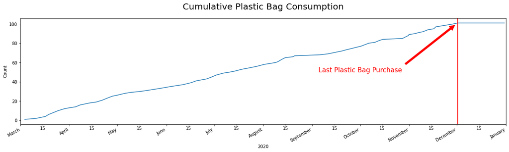

```python
import matplotlib.dates as mdates
from matplotlib.dates import DateFormatter
from pandas.plotting import register_matplotlib_converters
register_matplotlib_converters()

df = plastic_bags_df.groupby('ticket_date').agg({'count': 'sum'}).sort_values('ticket_date')
df.loc[datetime(2020, 12, 31)] = [0]
df['cumsum'] = df['count'].cumsum()

fig, ax = plt.subplots(figsize=(20, 5))
ax.set_title('Cumulative Plastic Bag Consumption', **title_config)

ax.plot(df.index.values, df['cumsum'].values)
ax.axvline(x=plastic_bags_df.ticket_date.max(), color='red')
ax.annotate('Last Plastic Bag Purchase', xy=(end_date, plastic_bags_df['count'].sum()), color = 'red',
            xytext=(datetime(2020, 10,1), 50), arrowprops=dict(facecolor='red', shrink=0.05, edgecolor='red'),
            size=15, ha='center')
ax.xaxis.set_minor_formatter(DateFormatter('%d'))
ax.xaxis.set_minor_locator(mdates.DayLocator(bymonthday=[1, 15]))
ax.xaxis.set_major_formatter(DateFormatter('%B'))
ax.xaxis.set_major_locator(mdates.DayLocator(bymonthday=[1]))
ax.set(xlabel='2020', ylabel='Count', xlim=(datetime(2020, 3, 1), datetime(2021, 1, 1)))
fig.autofmt_xdate()
```

Mi consumo de bolsas ha sido prácticamente constante durante todo el año. Finalmente conseguí aplanar la curva (término por desgracia muy popular últimamente) a principios de diciembre donde fue cuando compré mi última bolsa de plástico. Si sois tan curiosos como yo os preguntareis ¿por qué en esa fecha? Por una parte fue la conversación que os contaba en la introducción y por otra parte quizás la siguiente gráfica pueda daros una pista.

¿Qué tipos de bolsas he utilizado durante el 2020?

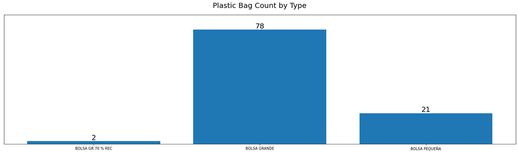

```python
fig, ax = plt.subplots(figsize=(20, 6))
df = plastic_bags_df.groupby('product_name').agg({'count': 'sum'}).reset_index().sort_values('product_name')
ax.set_title('Plastic Bag Count by Type', **title_config)
ax.bar(x=range(len(df)), height=df['count'])
for n, height in enumerate(df['count'].values):
    ax.text(n, height + 1 ,'{:.0f}'.format(height), ha='center', size=20)
ax.set(xticks=range(len(target_products)), xticklabels=target_products, ylim= (0, df['count'].max() + 10), yticks=())
fig.tight_layout()
```

¿Solo dos bolsas del tipo **"BOLSA GR 70 % REC"**? Pues ahí tenéis una pista. A finales de año el supermercado lanzó un nuevo tipo de bolsas que sustituían a las bolsas grandes (como podéis observar, las que más utilizaba). Estas bolsas son mucho más resistentes que sus equivalentes en tamaño y por lo tanto se prestan a ser utilizadas más veces. La lógica de que haya comprado dos y no ni una, ni tres, es que si recordáis mi media de utilización de bolsas es de 1.5 aproximadamente por visita por lo que con dos bolsas tengo más que suficiente.

## Conclusiones

Como era de esperar, el dinero invertido en bolsas de plástico no va a ser un gasto que vaya a hundir la economía de nadie (y quizás ese sea uno de los motivos de la proliferación de este tipo de productos). ¿No estaría mejor invertido ese dinero en la compra de unas bolsas reutilizables *super cool*? y digo más, ¿no sería mejor reutilizar las bolsas ya compradas y gastarnos ese dinero en otras cosas como por ejemplo, en una donación a algún tipo de organización benéfica? (todas las aportaciones suman, incluso las más pequeñas).

Está claro que no va a hundir tu economía pero puede que sí hunda al medio ambiente. ¡Ojo con el número! **150 bolsas de plástico en un año** y yo a fin de cuentas formo parte de un núcleo familiar unipersonal ¿Cuánto gasto de bolsas de plástico puede llegar a hacer una familia más grande? Una respuesta muy típica sería decir: *"Prefiero ni pensarlo"*. Pero no debemos ignorar el problema. Es vital pensar en él y tenerlo siempre muy presente.

## Agradecimientos

Me gustaría agradecer a todos los lectores que han invertido parte de su tiempo a leer este documento. Especialmente a aquellos que han tenido fuerzas para leerlo todo y llegar hasta aquí. También me gustaría agradecer muy especialmente a *Carol* por sus ánimos, consejos y correcciones.